# Intro to Data Analysis with R: Session 2

UCI Data Science Initiative

April 20, 2018

## Session 2 - Agenda

1. R Packages, Functions & Help
2. Exploratory Data Analysis
   - Numeric Summary Statistics
   - Histograms
   - Boxplots
   - Scatterplot Matrices

## Packages

- R packages are a way to maintain collections of R functions and data sets
- Packages allow for easy, transparent and cross-platform extension of the R base system

## Packages

- Terminology:
  - *Package*: an extension of the R base system with code, data and documentation in a standardized format
  - *Library*: a directory containing installed packages
  - *Repository*: a website providing packages for installation
  - *Source*: the original version of a package with human-readable text and code
  - *Base packages*: part of the R source tree, maintained by R Core
- For more info on how R packages are developed, please read [Creating R Packages: A Tutorial](http://cran.r-project.org/doc/contrib/Leisch-CreatingPackages.pdf) by Friedrich Leisch.
- Go to https://cran.r-project.org/web/packages/ for a list of all available packages.

## Installing a Package

There are two main ways to install a package in R:

1. Installing from CRAN: install a package directly from the repository
   - Using R studio: `Tools > Install Packages...`
   - From R console: `install.packages()`
2. Installing from source: first download the add-on R package and then type the following in your console:
   - `install.packages("path_to_file", repos = NULL, type = "source")`

Once you install a package, you need to load it into R using the function `library()`

## Installing a Package, contd.

Let’s install the package `car` that we will need later in this lecture.

```r
install.packages("car")  # install the package
library(car)  # load it into your R workspace
```

## Popular Packages

- To visualize data:
  - `ggplot2`: to create beautiful graphics
  - `googleVis`: to use Google Chart tools
- To report results:
  - `shiny`: to create interactive web-based apps
  - `knitr`: to combine R codes and Latex/Markdown codes
  - `slidify`: to build HTML 5 slide shows
- To write high-performance R code:
  - `rcpp`: to write R functions that call C++ code
  - `data.table`: to organize datasets for fast operations
  - `parallel`: to use parallel processing in R

## Functions in R

- Consider the function `sample()`.
- Run ?sample to read the help file.

```r
?sample
```

- `sample()` has four arguments:
  - `x`: vector of elements from which to choose
  - `size`: desired sample size
  - `replace`: sampling with/without replacement (logical)
  - `prob`: vector of probability weights
- The help file will specify which arguments have default values (and what those values are)

## Calling a Function in R

Function arguments can either be matched by position within the parentheses or by name

```r
sampSpace <- 1:6
sample(sampSpace, 1)  # arguments with default values can be omitted
```

```
## [1] 4
```

```r
sample(size = 1, x = sampSpace)  # no need to remember the order
```

```
## [1] 4
```

```r
sample(size = 1, sampSpace)
```

```
## [1] 3
```

## Some Useful Functions

- `str()`: a function to explain internal structure of an object
- `summary()`: a function that summarizes variables in a data frame
  - Note: this function is also used to summarize results of model fitting functions, which we will go over in the afternoon.

## `str()`

Compact way of understanding what an object is and what it contains

```r
str(str)
```

```
## function (object, ...)
```

```r
str(sample)
```

```
## function (x, size, replace = FALSE, prob = NULL)
```

## `str()`

After loading a data frame, it is often useful to use `str()` in order to understand the structure of your data.

```r
prestige <- read.table(file = here::here("data", "prestige_v2.csv"),
                       sep=",",
                       header=TRUE,
                       row.names=1)
str(prestige)
```

```
## 'data.frame':    101 obs. of  6 variables:
##  $ education: num  13.1 12.3 12.8 11.4 14.6 ...
##  $ income   : int  12351 25879 9271 8865 8403 11030 8258 14163 11377 11023 ...
##  $ women    : num  11.16 4.02 15.7 9.11 11.68 ...
##  $ prestige : num  68.8 69.1 63.4 56.8 73.5 77.6 72.6 78.1 73.1 68.8 ...
##  $ census   : int  1113 1130 1171 1175 2111 2113 2133 2141 2143 2153 ...
##  $ type     : Factor w/ 3 levels "bc","prof","wc": 2 2 2 2 2 2 2 2 2 2 ...
```

## `summary()`

Another useful function for understanding your data by providing a numeric summary of each attribute (column).

```r
summary(prestige)
```

```
##    education         income          women          prestige
##  Min.   : 6.38   Min.   :  611   Min.   : 0.00   Min.   :14.80
##  1st Qu.: 8.43   1st Qu.: 4075   1st Qu.: 3.59   1st Qu.:35.20
##  Median :10.51   Median : 5902   Median :13.62   Median :43.50
##  Mean   :10.73   Mean   : 6784   Mean   :29.19   Mean   :46.76
##  3rd Qu.:12.71   3rd Qu.: 8131   3rd Qu.:52.27   3rd Qu.:59.60
##  Max.   :15.97   Max.   :25879   Max.   :97.51   Max.   :87.20
##      census       type
##  Min.   :1113   bc  :47
##  1st Qu.:3117   prof:31
##  Median :5137   wc  :23
##  Mean   :5422
##  3rd Qu.:8313
##  Max.   :9517
```

## Exploratory Data Analysis

- Before performing statistical analyses on your data, it is important to do exploratory data analysis (EDA) in order to better understand the variables and the relationships between them.
- This can be done in many ways
  - Numeric summaries (e.g., using `str()` and `summary()`)
  - Plots, plots, and more plots
  - More advanced methods (variograms, empirical covariance matrices, etc)
- We will cover some of the basic plotting functions.

## Plotting in R

- To explore the distribution of one variable:
  - Histograms
  - Boxplots
- To explore relationships between variables:
  - Grouped Boxplots
  - Scatterplots
  - Scatterplot Matrices
- Useful resources:
  - [Quick-R Graphical Parameters](https://www.statmethods.net/advgraphs/parameters.html)
  - [`ggplot2`](http://ggplot2.tidyverse.org/)
  - Search for (or post) specific questions on [stackoverflow](https://stackoverflow.com/questions/tagged/r), which is a community that will answer questions & chose the best solutions via voting
- *NOTE: This course provides a basic introduction to `R`’s plotting capabilities. You can do much, much more elegant plots in `R`!*

## Histograms

- One of the most basic plots in R is a histogram.
- Let’s plot a histogram of the response variable `prestige`.
  - `freq`: logical variable that controls the type of histogram (`TRUE` gives counts, `FALSE` gives relative counts)
  - `breaks`: controls the number of bins & bin locations; multiple ways to set this
  - We can add arguments to the function to change the bar colors, title, and axis labels.

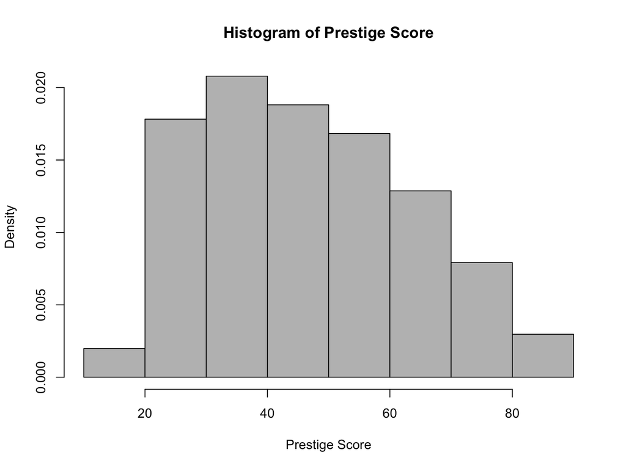

```r
hist(prestige$prestige, freq = FALSE,
     col = "grey",
     main = "Histogram of Prestige Score",
     xlab = "Prestige Score")
```

## Histograms, contd.

- Let’s add a dashed vertical line at the median of prestige using `abline()`
  - Adds a straight line to the current figure
  - Can be specified multiple ways–intercept/slope, horizontal/vertical location, regression coefficients/object
  - Not unique to histograms–you can use `abline` on (almost) any figure

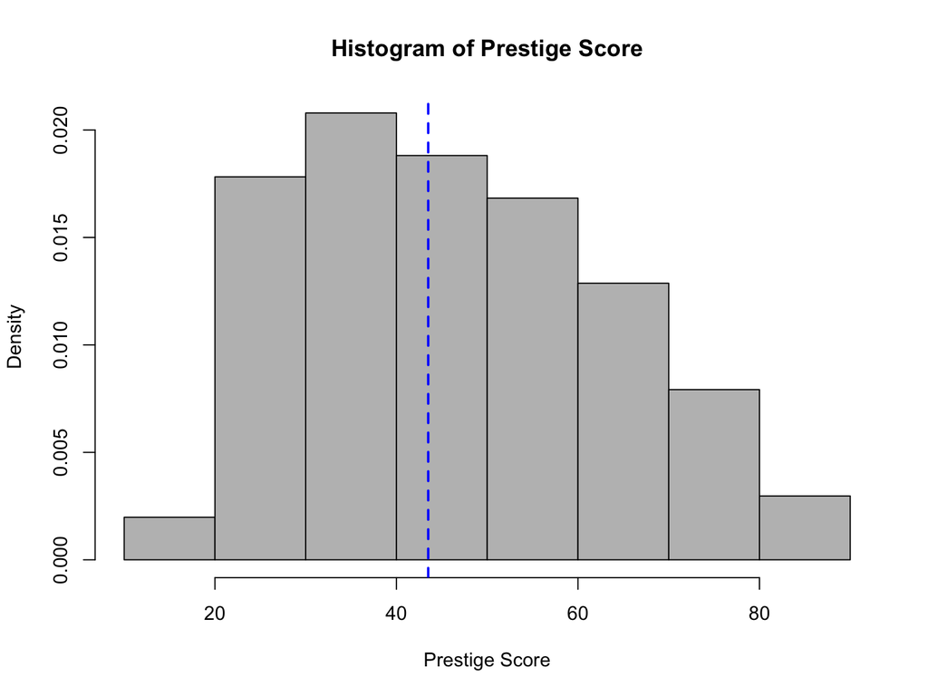

```r
hist(prestige$prestige, freq = FALSE, col = "grey",
     main = "Histogram of Prestige Score", xlab = "Prestige Score")
abline(v = median(prestige$prestige), col = "blue", lty = 2, lwd = 2)
```

## Histograms, contd.

- Sometimes we would rather have a smoothed version of a histogram (i.e., a *density* function).
  - Not susceptible to number/location of bins like histograms are.
- We can include this using the `density()` and `lines()` functions.
  - `lines()`: takes coordinate pairs (in multiple input formats) and adds them to current figure connected by line segments
  - `density()`: computes kernel density estimates (a smoothed histogram); see `?density` for more details

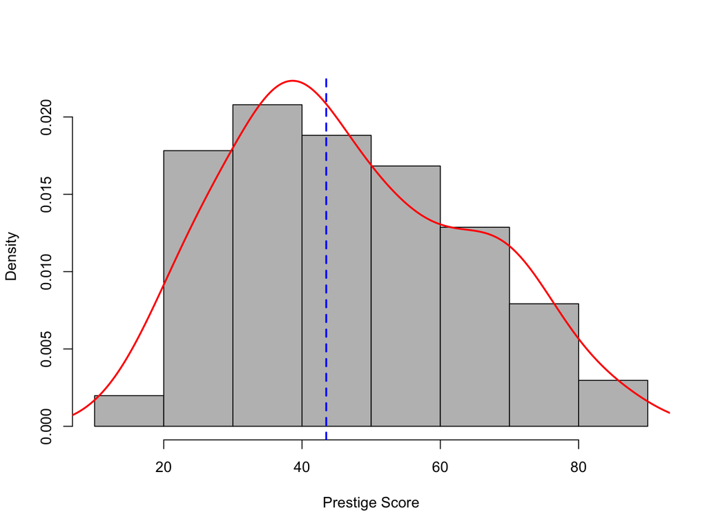

```r
hist(prestige$prestige, freq=FALSE, col = "grey", main = "", xlab = "Prestige Score", ylim=c(0, 0.022))
abline(v = median(prestige$prestige), col = "blue", lty = 2, lwd = 2)
lines(density(prestige$prestige), col = "red", lwd = 2)
```

## Adding a Legend

- With multiple features on one figure, a legend can help clearly convey what is plotted.
- Use `legend()` to do this in R.
  - Very versatile function–look at its documentation
  - Best to play around with this on your own, iterating through multiple plots until you get the legend to appear how you want it

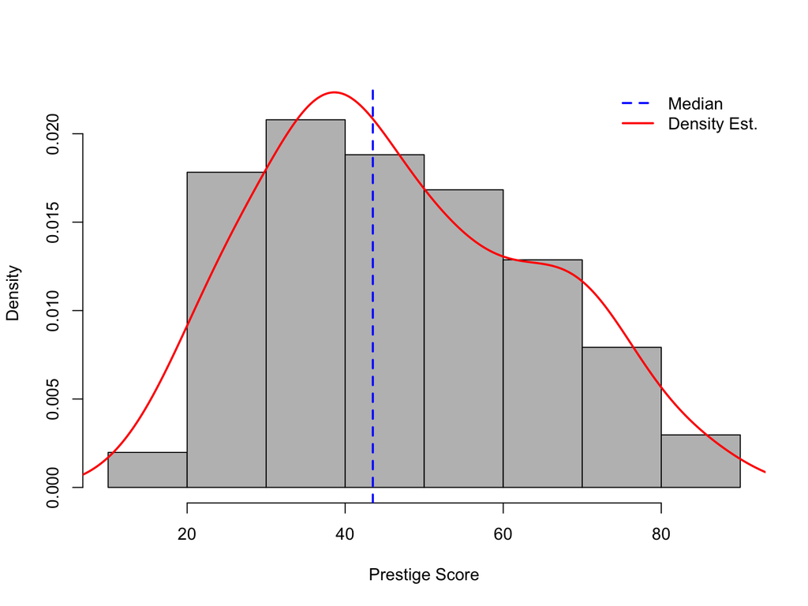

```r
hist(prestige$prestige, freq=FALSE, col = "grey", main = "", xlab = "Prestige Score", ylim=c(0, 0.022))
abline(v = median(prestige$prestige), col = "blue", lty = 2, lwd = 2)
lines(density(prestige$prestige), col = "red", lwd = 2)
legend("topright", legend = c("Median", "Density Est."),
       col = c("blue", "red"), lty = c(2, 1), lwd = 2, bty = "n")
```

## Boxplots

- Provide a graphical representation of numeric summary statistics.
- Use `boxplot()` to produce them in R
- First let’s make a boxplot of the response variable `prestige`:

```r
summary(prestige$prestige)
```

```
##    Min. 1st Qu.  Median    Mean 3rd Qu.    Max.
##   14.80   35.20   43.50   46.76   59.60   87.20
```

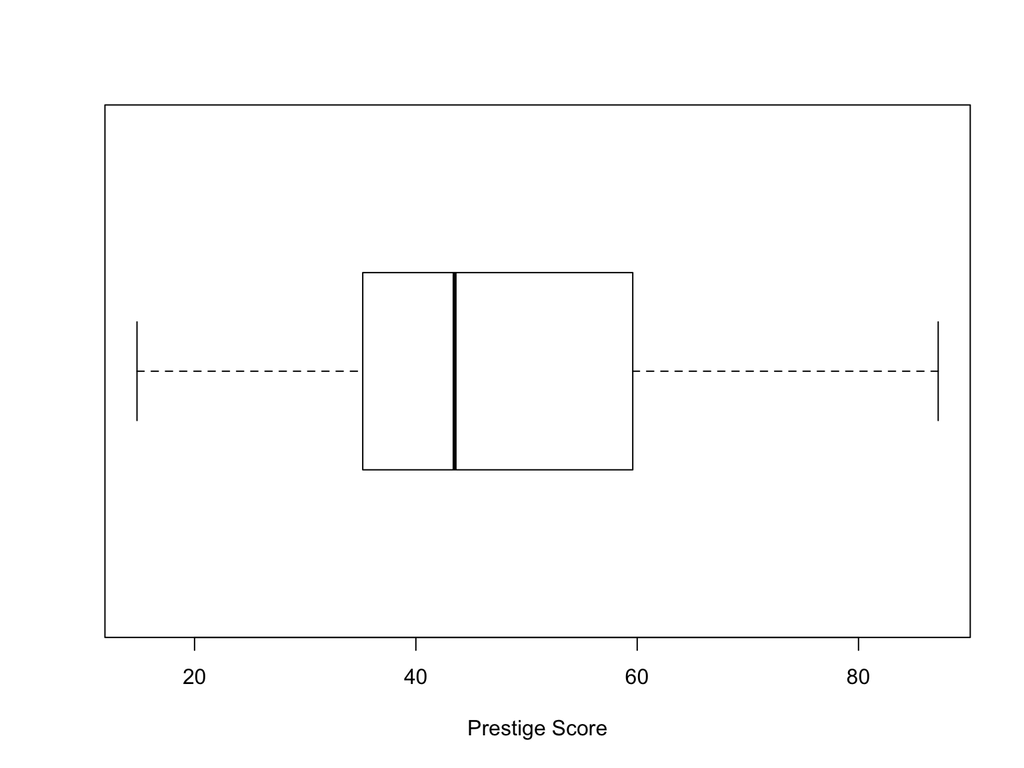

```r
boxplot(prestige$prestige, horizontal = TRUE, xlab = "Prestige Score")
```

## Grouped Boxplots

- Used to investigate relationships between variables:
  - Continuous variable & factor (most common)
  - Two continuous variables (group one of them)
- Let’s look at a boxplot of `prestige` grouped by `type`

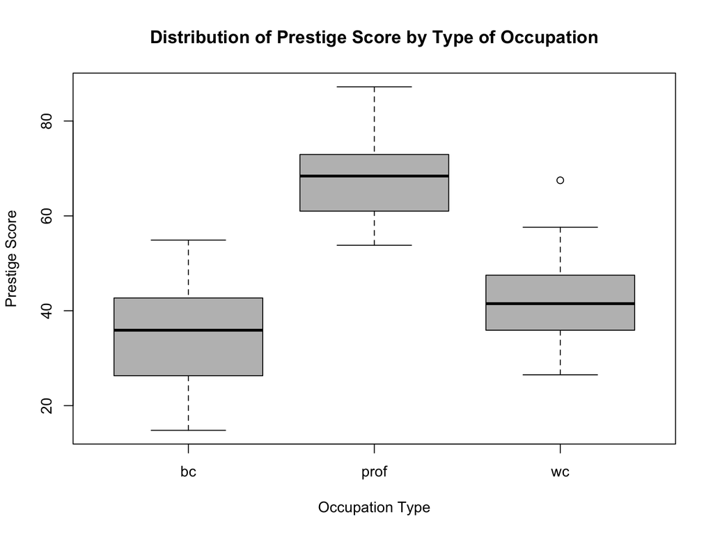

```r
boxplot(prestige ~ type, data = prestige, col = "grey",
        main = "Distribution of Prestige Score by Type of Occupation",
        xlab = "Occupation Type", ylab = "Prestige Score")
```

## Scatterplots

- We can also use scatterplots to visualize the relationship between two (continuous) variables.
- We use the `plot()` function to do this
  - Extremely flexible–there are plot methods for a variety of objects! (e.g., plotting a regression object returns diagnostic plots… more on this later)
  - See the help documentation (`?plot`) and [Graphical Parameters](https://www.statmethods.net/advgraphs/parameters.html) for more details
- For now, focus on the most simple plot where we specify the `x` and `y` coordinates.
  - `x` and `y` must be the same dimension

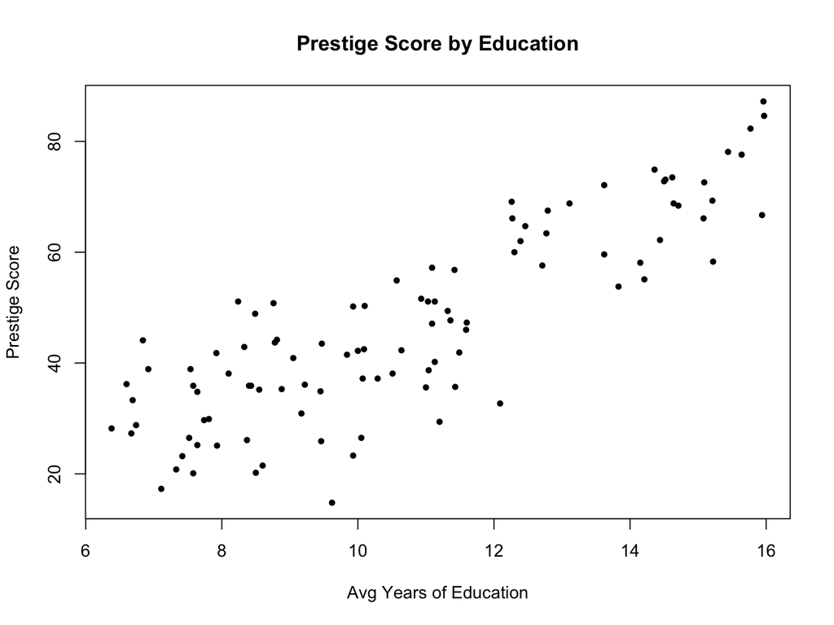

```r
plot(x = prestige$education, y = prestige$prestige, type = "p", pch = 20,
     main = "Prestige Score by Education",
     xlab = "Avg Years of Education", ylab = "Prestige Score")
```

## Scatterplots, contd.

- Let’s overlay both a linear fit and smoother to our scatterplot.
- We can include this using the `lowess()`, `lines()`, and `abline()` functions.
  - We’ve already used `lines()` and `abline()`
  - Need to use `lm()` to fit a linear regression, more on this later
  - `lowess()`: computes a smoothed fit using locally-weighted polynomial regression (LOWESS); don’t worry about the details here, just need to know it is an unbiased way (no assumptions) to estimate relationship between two variables

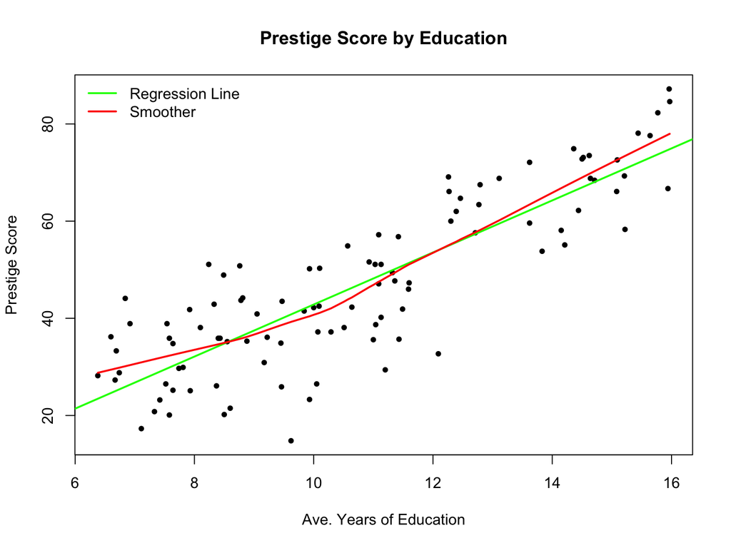

```r
plot(prestige$education, prestige$prestige, type = "p", pch = 20,
     main = "Prestige Score by Education",
     xlab = "Ave. Years of Education", ylab = "Prestige Score")
abline(reg = lm(prestige ~ education, data = prestige), col = "green", lwd = 2)  # linear regression
lines(lowess(x = prestige$education, y = prestige$prestige), col = "red", lwd = 2)  # smoother
legend("topleft", legend = c("Regression Line", "Smoother"), col = c("green", "red"),
       lwd = c(2,2), lty = 1, bty = "n")
```

## Scatterplot Matrices

- The function `scatterplotMatrix()` (found in the `car` package we installed earlier) produces scatterplots between all variables in a data frame.
- We can use direct ordering of the variables to control the order in which they are plotted.

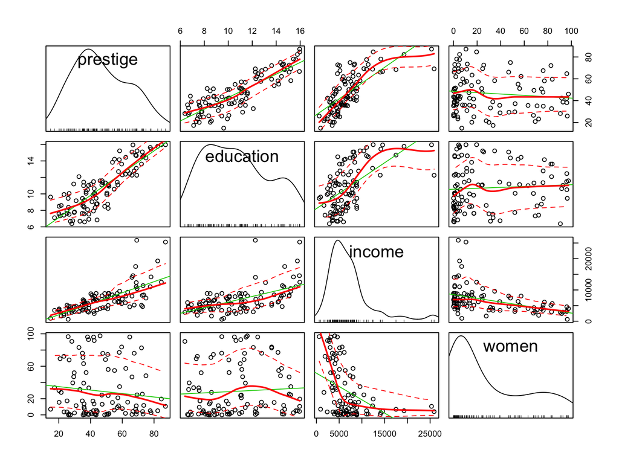

```r
library(car)
scatterplotMatrix( prestige[ ,c("prestige","education","income","women")] )
```

## End of Session 2

Next up:

1. [Exercise 2](http://ucidatascienceinitiative.github.io//IDA-with-R/exercises/ex_2.html)
2. Lunch

**Return at 1:00 to discuss solutions to Exercise 2!**